# Formation R initiation

Le menu Session > Set Working Directory permet de sélectionner le répertoire par défaut contenant vos scripts et éventuels fichiers de données. Vous pouvez également le modifier via une ligne de code :

```r
setwd('C:/Users/Stephanie/Desktop/R_initiation')
```

Dans Rstudio pour compiler une ligne, vous pouvez placer le curseur dessus et cliquer sur Run, ou bien utiliser le raccourci clavier ctrl+entrée

# Opérations de base

Sous R, les éléments de base sont des objets : vecteurs, matrices, listes, table … Ces objets peuvent contenir des éléments de type numérique, booléen (logical : TRUE, FALSE), chaîne de caractère (string), facteur (factor, pour les variables qualitatives prenant un nombre déterminé de modalité). La différence entre la table de données (data.frame) et la matrice est tient notamment dans le fait que la première peut contenir des éléments mixtes.

### Objets et opérations simples

On commence par créer des éléments pour illustrer les opérations de base en R. Le signe `<-` permet d’assigner un contenu à une variable dont on indique le nom à gauche.

```r
element_a <- 2
element_a
```

```
## [1] 2
```

```r
element_b <- 3
element_b
```

```
## [1] 3
```

```r
element_c <- element_a/2 + 2*element_b # les opérations -, *, /, sqrt pour racine, ^ pour puissance, log, exp, sont également possibles !
element_c
```

```
## [1] 7
```

On peut travailler très naturellement sur des vecteurs

```r
vecteur_a <- c(2,3,5)
vecteur_a
```

```
## [1] 2 3 5
```

On peut récupérer un élément d’un vecteur avec l’opérateur `[`

```r
vecteur_a[1] #on commence à numéroter à partir de 1 (et non de zéro)
```

```
## [1] 2
```

```r
vecteur_a[c(1,3)]
```

```
## [1] 2 5
```

Dans le cas où le vecteur correspond à une séquence de nombres, on peut utiliser une syntaxe particulière

```r
vecteur_a <- c(2,3,4)
vecteur_b <- 2:4
vecteur_c <- seq(2,4,1) # les arguments de la fonction seq (séquence) correspondent à from, to, by (à partir de 1, jusqu'à 10, avec des écarts de 2)

vecteur_a == vecteur_b
```

```
## [1] TRUE TRUE TRUE
```

```r
variable_logique_a <- vecteur_a == vecteur_b
```

Les opérations sur les vecteurs sont très proches des opérations sur les éléments. Une opération entre un vecteur a et un vecteur b revient à réaliser l’opération entre les couples d’éléments issus des deux vecteurs et situés à la même place (il faut que les vecteurs admettent la même taille pour que ça ait un sens)

```r
vecteur_c <- 2*vecteur_c # on écrase la valeur du vecteur_c
vecteur_c + vecteur_a/2 # exemple d'opération entre deux vecteurs
```

```
## [1]  5.0  7.5 10.0
```

Le vecteur est caractérisé notamment par sa taille

```r
length(vecteur_a)
```

```
## [1] 3
```

Il peut-être trié :

```r
vecteur_d <- c(3,2,1)
order(vecteur_d)
```

```
## [1] 3 2 1
```

```r
sort(vecteur_d)
```

```
## [1] 1 2 3
```

Remarque, si on ne sait plus la signification des trois arguments de `seq`, on peut aller dans l’aide avec `?seq`

```r
liste_a <- list(2,3,5)
liste_a
```

```
## [[1]]
## [1] 2
##
## [[2]]
## [1] 3
##
## [[3]]
## [1] 5
```

```r
liste_a[[2]]
```

```
## [1] 3
```

```r
liste_b <- list(sexe = 2, age = 3, salaire = 5)
liste_b$age # si on donne des noms aux éléments de la liste, on peut les récupérer via l'opérateur $
```

```
## [1] 3
```

La fonction `length` convient aussi pour les listes

```r
length(liste_a)
```

```
## [1] 3
```

Pour les matrices :

```r
matrice_a <- matrix(1:15,ncol=5) # exemple d'une matrice remplie des chiffres consécutifs de 1 à 15 rangés sur 5 colonnes
matrice_a
```

```
##      [,1] [,2] [,3] [,4] [,5]
## [1,]    1    4    7   10   13
## [2,]    2    5    8   11   14
## [3,]    3    6    9   12   15
```

```r
head(matrice_a) # la fonction head permet de visualiser un extrait des données
```

```
##      [,1] [,2] [,3] [,4] [,5]
## [1,]    1    4    7   10   13
## [2,]    2    5    8   11   14
## [3,]    3    6    9   12   15
```

```r
matrice_a[1,2] # pour récupérer l'élément de la première ligne et de la deuxième colonne
```

```
## [1] 4
```

Par défaut, les opérations mathématiques simples se font élément par élément

```r
matrice_b <- 2*matrice_a
matrice_a
```

```
##      [,1] [,2] [,3] [,4] [,5]
## [1,]    1    4    7   10   13
## [2,]    2    5    8   11   14
## [3,]    3    6    9   12   15
```

```r
matrice_b
```

```
##      [,1] [,2] [,3] [,4] [,5]
## [1,]    2    8   14   20   26
## [2,]    4   10   16   22   28
## [3,]    6   12   18   24   30
```

```r
matrice_b - matrice_a # les opérations se font éléments par élément
```

```
##      [,1] [,2] [,3] [,4] [,5]
## [1,]    1    4    7   10   13
## [2,]    2    5    8   11   14
## [3,]    3    6    9   12   15
```

```r
t(matrice_b)%*% matrice_a # pour faire des vrais produits matriciels, on utilise l'opérateur %*%, ici t() indique que l'on prend également la transposée
```

```
##      [,1] [,2] [,3] [,4] [,5]
## [1,]   28   64  100  136  172
## [2,]   64  154  244  334  424
## [3,]  100  244  388  532  676
## [4,]  136  334  532  730  928
## [5,]  172  424  676  928 1180
```

Les dimensions de la matrice peuvent être obtenues de la manière suivante :

```r
nrow(matrice_a)
```

```
## [1] 3
```

```r
ncol(matrice_a)
```

```
## [1] 5
```

```r
dim(matrice_a)
```

```
## [1] 3 5
```

Les tables de données ou data.frame est sans doute le format qu’on utilisera le plus dans la suite.

```r
df_a <- as.data.frame(matrice_a) # on commence par transformer la matrice en data.frame, l'opération symétrique as.matrix() est possible
head(df_a)
```

|  | V1 | V2 | V3 | V4 | V5 |
| --- | --- | --- | --- | --- | --- |
| 1 | 1 | 4 | 7 | 10 | 13 |
| 2 | 2 | 5 | 8 | 11 | 14 |
| 3 | 3 | 6 | 9 | 12 | 15 |

```r
names(df_a) # ici le data.frame provient de la conversion d'une matrice, il n'y a donc pas de noms de colonnes à part ceux qui sont donnés par défaut V1, V2...
```

```
## [1] "V1" "V2" "V3" "V4" "V5"
```

```r
names(df_a) <- c('a','b','c','d','e') # on peut changer le nom des colonnes simplement
```

Pour récupérer de l’information dans la table de données, on peut procéder de différentes manières

```r
df_a$b # avec l'opérateur $, on peut récupérer directement la colonne b
```

```
## [1] 4 5 6
```

```r
df_a['b'] # revient au même
```

| b |
| --- |
| 4 |
| 5 |
| 6 |

```r
df_a[2] # correspond également car il s'agit de la 2e colonne
```

| b |
| --- |
| 4 |
| 5 |
| 6 |

```r
df_a$e <- 1 # permet de construire une nouvelle colonne e remplie de 1
head(df_a)
```

|  | a | b | c | d | e |
| --- | --- | --- | --- | --- | --- |
| 1 | 1 | 4 | 7 | 10 | 1 |
| 2 | 2 | 5 | 8 | 11 | 1 |
| 3 | 3 | 6 | 9 | 12 | 1 |

```r
df_a$f <- df_a$a + df_a$b # permet de construire une nouvelle colonne qui serait la somme des deux premières, les opération -, *, /, sqrt pour racine carrée, log, exp, ^, sont également possibles !
head(df_a)
```

|  | a | b | c | d | e | f |
| --- | --- | --- | --- | --- | --- | --- |
| 1 | 1 | 4 | 7 | 10 | 1 | 5 |
| 2 | 2 | 5 | 8 | 11 | 1 | 7 |
| 3 | 3 | 6 | 9 | 12 | 1 | 9 |

```r
df_a$f <- sqrt(df_a$a) + df_a$b^2 # permet de construire une nouvelle colonne qui serait la somme des deux premières, les opération -, *, /, sqrt pour racine
```

Vérifions le type de ces objets avec la fonction `class`

```r
class(element_a)
```

```
## [1] "numeric"
```

```r
class(vecteur_a)
```

```
## [1] "numeric"
```

```r
class(variable_logique_a)
```

```
## [1] "logical"
```

```r
class(liste_a)
```

```
## [1] "list"
```

```r
class(matrice_a)
```

```
## [1] "matrix"
```

```r
class(df_a)
```

```
## [1] "data.frame"
```

Nous avons créé un certain nombre de variables qui sont disponibles dans votre environnement (généralement en haut à droite par défaut) On peut aussi utiliser la fonction `ls` pour voir la liste des objets dont on dispose, et `rm` pour en supprimer.

```r
ls()
```

```
##  [1] "df_a"               "element_a"          "element_b"
##  [4] "element_c"          "liste_a"            "liste_b"
##  [7] "matrice_a"          "matrice_b"          "variable_logique_a"
## [10] "vecteur_a"          "vecteur_b"          "vecteur_c"
## [13] "vecteur_d"
```

```r
rm(element_a)
ls()
```

```
##  [1] "df_a"               "element_b"          "element_c"
##  [4] "liste_a"            "liste_b"            "matrice_a"
##  [7] "matrice_b"          "variable_logique_a" "vecteur_a"
## [10] "vecteur_b"          "vecteur_c"          "vecteur_d"
```

### Boucle, condition

Reprenons le cas où on a un data.frame simple. On veut calculer la moyenne, la somme, le maximum et le minimum de chaque colonne.  
Une manière de le faire serait de faire une boucle sur le nombre de colonnes et d’appliquer la fonction `mean`, `sum`, `max`, `min`, à chaque colonne tour à tour.

```r
nb_col <- ncol(df_a)
mean_col <- NULL # on commence par créer une variable vide, dans laquelle on va ajouter itérativement les moyenne de chaque colonne

for (i in 1:nb_col){
  print(i)
  mean_temp <- mean(df_a[i])
  print(mean_temp)
  mean_col <- c(mean_col, mean_temp)
  print(mean_col)
  print('---------')
}
```

```
## [1] 1
## [1] NA
## [1] NA
## [1] "---------"
## [1] 2
## [1] NA
## [1] NA NA
## [1] "---------"
## [1] 3
## [1] NA
## [1] NA NA NA
## [1] "---------"
## [1] 4
## [1] NA
## [1] NA NA NA NA
## [1] "---------"
## [1] 5
## [1] NA
## [1] NA NA NA NA NA
## [1] "---------"
## [1] 6
## [1] NA
## [1] NA NA NA NA NA NA
## [1] "---------"
```

En réalité, les boucles sont à éviter en R, elles ne sont pas efficaces, on leur préférera la fonction `lapply` qui distribue la fonction souhaitée sur chaque élément d’une liste. Un data.frame peut-être vu comme une liste de vecteurs.

```r
mean_col <- lapply(df_a, mean) # ici la fonction est particulièrement simple car mean est déjà une fonction R
mean_col
```

```
## $a
## [1] 2
##
## $b
## [1] 5
##
## $c
## [1] 8
##
## $d
## [1] 11
##
## $e
## [1] 1
##
## $f
## [1] 27.04875
```

Admettons qu’on cherche à appliquer une fonction personnalisée

```r
mean_personnalisee <- function(vect){
  return(sum(vect)/length(vect))
}
```

```r
mean_col <- lapply(df_a, function(vect) mean_personnalisee(vect))
mean_col
```

```
## $a
## [1] 2
##
## $b
## [1] 5
##
## $c
## [1] 8
##
## $d
## [1] 11
##
## $e
## [1] 1
##
## $f
## [1] 27.04875
```

Appliquée sur un vecteur, `lapply` le convertit en liste, on peut repasser à un format vecteur avec la fonction `unlist`

```r
fonction_personnalisee <- function(x){
  return(x*log(x))
}
```

```r
vecteur_a_transforme <- lapply(vecteur_a, function(x) fonction_personnalisee(x))
class(vecteur_a_transforme)
```

```
## [1] "list"
```

```r
vecteur_a_transforme
```

```
## [[1]]
## [1] 1.386294
##
## [[2]]
## [1] 3.295837
##
## [[3]]
## [1] 5.545177
```

```r
unlist(vecteur_a_transforme)
```

```
## [1] 1.386294 3.295837 5.545177
```

```r
vecteur_a*log(vecteur_a) # aurait marché aussi !
```

```
## [1] 1.386294 3.295837 5.545177
```

`apply` s’applique aussi à des matrices, on indique alors si la fonction à distribuer doit être distribuée en ligne ou en colonne

```r
matrice_a
```

```
##      [,1] [,2] [,3] [,4] [,5]
## [1,]    1    4    7   10   13
## [2,]    2    5    8   11   14
## [3,]    3    6    9   12   15
```

```r
apply(matrice_a,1,sum) # ici on applique la fonction somme, autrement dit on somme les éléments par ligne
```

```
## [1] 35 40 45
```

```r
apply(matrice_a,2,sum) # par colonne
```

```
## [1]  6 15 24 33 42
```

La syntaxe de la condition est très proche de celle de la boucle, sauf que l’on remplace `for` par `if`

```r
fonction_personnalisee <- function(x){
  if (x>0){res <- x*log(x)}
  else {res <- 0}
  return(0)
}
```

```r
vecteur_d <- c(0,-1,2)
unlist(lapply(vecteur_d, function(x) fonction_personnalisee(x)))
```

```
## [1] 0 0 0
```

```r
abs(vecteur_d) # rmq : abs permet de passer un élément en valeur absolue (s'applique également aux vecteurs sans recours à lapply)
```

```
## [1] 0 1 2
```

Ici on a inclus la condition dans une fonction, mais ce n’est pas indispensable ! On peut vouloir aussi tester la différence `!=` plutôt que l’égalité, ‘<’ ou ‘>’, et si on a plusieurs conditions, on mettra chacune entre parenthèse et on utilisera `|` pour dire “ou” et `&` pour dire “et” (par exemple `(b-3==a) & (b>=a)`).

Parfois, on n’a pas besoin de passer par `if` pour appliquer une condition, par exemple si on veut récupérer seulement les éléments de vecteur_d supérieurs ou égaux à 0. Cela revient à dire qu’on teste la condition sur chaque élément et qu’on conserve vecteur_d[i] pour i tel que vecteur_d[i]>=0

```r
vecteur_d[vecteur_d>=0]
```

```
## [1] 0 2
```

Et ça fonctionne aussi avec les data.frames

```r
df_a[df_a$a>2] # on ne garde que les colonnes qui vérifient cette condition
```

| c | f |
| --- | --- |
| 7 | 17.00000 |
| 8 | 26.41421 |
| 9 | 37.73205 |

### Le type chaîne de caractère

Il arrive que les objets que l’on manipule ne soit pas numériques, on parle alors de `character` ou de `factor`. C’est le cas par exemple des noms de colonnes de `df_a`

```r
class(names(df_a))
```

```
## [1] "character"
```

On peut aussi réaliser des opérations, par exemple de concaténation. Imaginons que l’on souhaite préciser les noms de colonnes en indiquant qu’il s’agit de département.

```r
paste('departement','test',sep='_')
```

```
## [1] "departement_test"
```

```r
paste(rep('departement',5), names(df_a),sep='_') # revient à faire apply de paste sur tous les éléments du vecteur names(df_a)
```

```
## [1] "departement_a" "departement_b" "departement_c" "departement_d"
## [5] "departement_e" "departement_f"
```

```r
rep('departement',5) # rep est la fonction qui permet de créer des vecteurs d'une taille donnée contenant toujours le même élément qui pourrait être numérique
```

```
## [1] "departement" "departement" "departement" "departement" "departement"
```

On peut récupérer une partie d’une chaine de caractère simplement

```r
character_a <- 'departement_a'
class(character_a)
```

```
## [1] "character"
```

```r
substr(character_a,1,10)
```

```
## [1] "departemen"
```

```r
strsplit(character_a,'_')
```

```
## [[1]]
## [1] "departement" "a"
```

```r
strsplit(character_a,'_')[[1]][[2]]
```

```
## [1] "a"
```

La taille d’une chaine de caractères correspond au nombre de caractères

```r
nchar(character_a)
```

```
## [1] 13
```

Les facteurs correspondent aux modalités d’une variable qualitative.

```r
col_df_a <- names(df_a)
col_df_a_fact <- as.factor(col_df_a)
is.character(col_df_a_fact)
```

```
## [1] FALSE
```

```r
class(col_df_a)
```

```
## [1] "character"
```

```r
class(col_df_a_fact)
```

```
## [1] "factor"
```

On ne peut pas rajouter un élément qui n’est pas dans la liste des facteurs naïvement

```r
levels(col_df_a_fact)
```

```
## [1] "a" "b" "c" "d" "e" "f"
```

```r
col_df_a_fact <- c(col_df_a_fact, 'departement_z')
class(col_df_a_fact) # attention cette opération a converti col_df_a_fact en character
```

```
## [1] "character"
```

```r
col_df_a_fact
```

```
## [1] "1"             "2"             "3"             "4"
## [5] "5"             "6"             "departement_z"
```

```r
levels(col_df_a_fact)
```

[output not shown]

```r
col_df_a_fact <- as.factor(col_df_a)
as.character(col_df_a_fact) # parfois on préfère revenir aux chaines de caractères pour éviter ce type de problèmes
```

```
## [1] "a" "b" "c" "d" "e" "f"
```

Lorsque l’on charge des tables de données, il est possible que R ne reconnaisse pas une variable numérique et qu’elle soit codée en facteurs. Dans ce cas, il faut la convertir en chaines de caractères avant de la convertir en nombre, car les facteurs sont associés à des numéros qui correspondent aux modalités.

```r
nombres <- c(4,2,3)
facteurs <- as.factor(nombres)
facteurs
```

```
## [1] 4 2 3
## Levels: 2 3 4
```

```r
as.numeric(facteurs)
```

```
## [1] 3 1 2
```

```r
as.numeric(as.character(facteurs))
```

```
## [1] 4 2 3
```

# Générer des variables aléatoires

```r
n <- 10
Y <- rnorm(n,20,5)

mean(Y) # moyenne
```

```
## [1] 21.44194
```

```r
sd(Y) # écart-type
```

```
## [1] 3.546439
```

```r
sd(Y)/sqrt(length(Y)) # écart-type de la moyenne
```

```
## [1] 1.121483
```

```r
summary(Y) # quartiles et moyenne
```

```
##    Min. 1st Qu.  Median    Mean 3rd Qu.    Max.
##   17.46   18.86   21.42   21.44   22.37   29.72
```

On peut représenter graphiquement cette variable

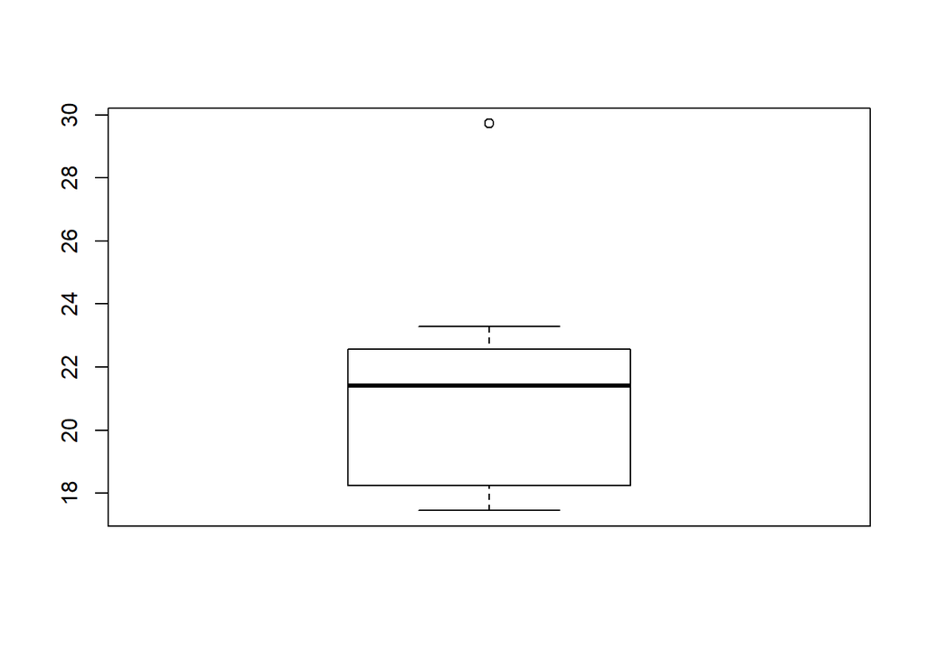

```r
boxplot(Y) # diagramme boîte
```

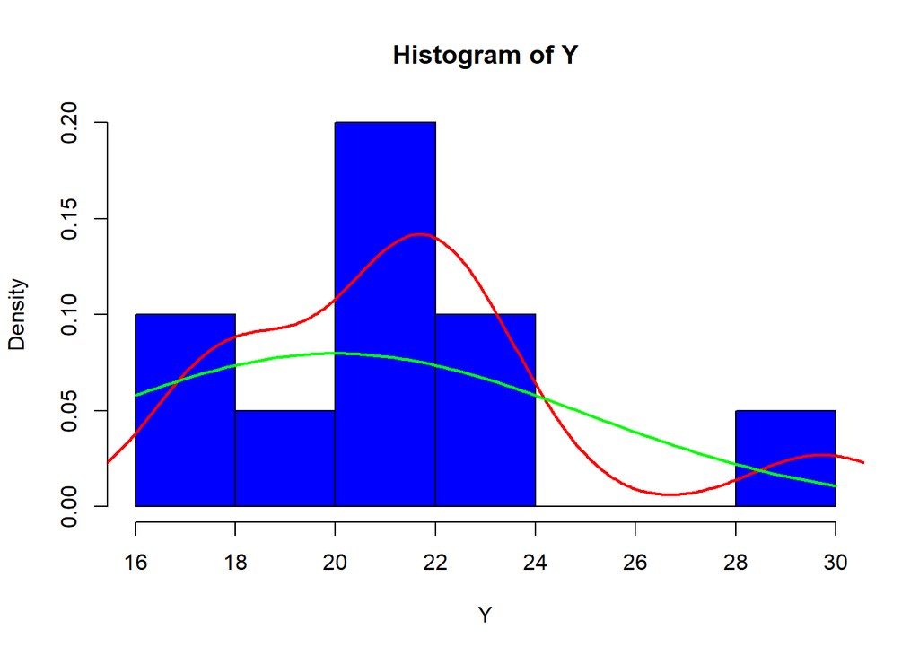

```r
hist(Y, probability=T, col="blue") # histogramme de la densité

lines(density(Y), col="red", lwd=2) # estimation par la méthode du noyau
# tracer la loi théorique
x <- 1:100
curve(dnorm(x,mean=20,sd=5),add=TRUE,col="green",lwd=2) # l'argument add permet de rajouter ce contour sur le graphique
```

On peut générer des observations tirées dans une loi uniforme sur [a,b]

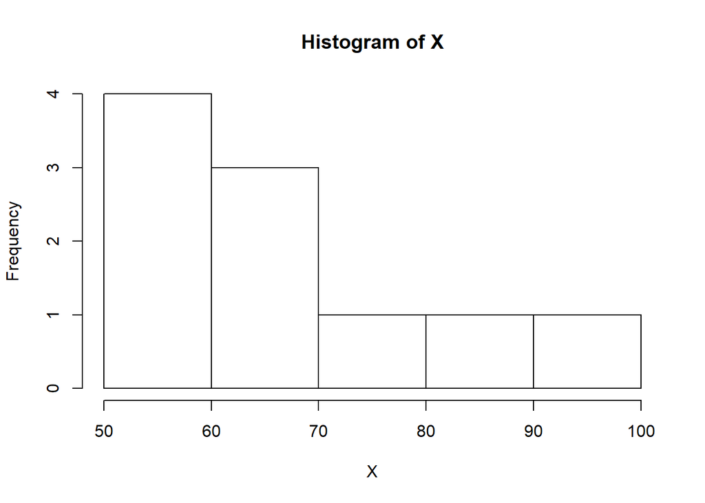

```r
X <- runif(n,50,100)
hist(X)
```

Vous pouvez augmenter la valeur de `n` pour voir ce que ça donne

# Lecture et exploration de données

Pour cette entrée en matière de l’exploration d’un vrai fichier de donnée, nous nous sommes fortement inspirés de l’exercice suivant https://www.math.univ-toulouse.fr/~besse/Wikistat/pdf/st-scenar-statlab.pdf

Une étude réalisée entre 1961 et 1973 dans la maternité d’un hôpital d’Oakland (Californie) avait pour but de rechercher si certaines caractéristiques des parents avaient une influence sur le développement de l’enfant. Parmi les variables collectées, 19 variables décrites dans le tableau ci-dessous ont été observées sur 115 familles ou unités statistiques. Ces variables décrivent des informations médicales et socio-économiques concernant le bébé et ses parents au moment de la naissance puis dix ans plus tard, permettant ainsi de se poser différentes questions de nature plutôt épidémiologique : - Influence ou non de la consommation de cigarettes sur le sexe de l’enfant, sur son poids, sur sa taille, - sur l’évolution du poids de la mère en 10 ans, - sur les liaisons entre les caractéristiques des parents (poids, taille, rhésus) et celles de leur enfant

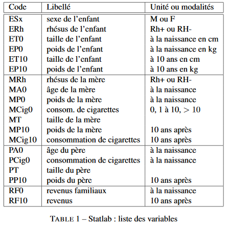

### Chargement et exploration sommaire

```r
famil=read.csv2("statlab.csv") # lecture du fichier csv
head(famil) # aperçu du haut des données
```

|  | ESx | ERh | ET0 | EP0 | ET10 | EP10 | MRh | MA0 | MP0 | MCig0 | MT | MP10 | MCig10 | PA0 | PCig0 | PT | PP10 | RF0 | RF10 |
| --- | --- | --- | --- | --- | --- | --- | --- | --- | --- | --- | --- | --- | --- | --- | --- | --- | --- | --- | --- |
| 1 | M | R+ | 49.5 | 3.18 | 136.0 | 39.9 | R+ | 18 | 61.0 | >10cig | 157.0 | 56.0 | 0cig | 26 | >10cig | 182.5 | 89.0 | 42 | 112 |
| 2 | M | R- | 48.5 | 2.45 | 124.5 | 23.1 | R- | 18 | 45.0 | >10cig | 164.5 | 48.5 | 1-10cig | 22 | >10cig | 178.0 | 66.0 | 37 | 140 |
| 3 | M | R- | 51.5 | 3.31 | 130.5 | 26.3 | R- | 20 | 55.0 | 1-10cig | 157.5 | 60.0 | 0cig | 21 | >10cig | 180.5 | 75.0 | 54 | 114 |
| 4 | M | R+ | 47.0 | 3.40 | 128.5 | 27.2 | R+ | 20 | 63.5 | >10cig | 166.0 | 65.5 | >10cig | 20 | >10cig | 180.5 | 86.0 | 86 | 180 |
| 5 | M | R+ | 51.0 | 2.86 | 133.0 | 29.9 | R+ | 20 | 46.5 | 1-10cig | 162.5 | 54.5 | 0cig | 21 | >10cig | 179.0 | 68.0 | 89 | 150 |
| 6 | M | R+ | 51.0 | 2.90 | 137.0 | 33.6 | R+ | 20 | 46.5 | >10cig | 162.0 | 55.0 | 1-10cig | 22 | 1-10cig | 167.5 | 68.5 | 96 | 126 |

```r
dim(famil) # combien de colonnes et de ligne
```

```
## [1] 115  19
```

```r
summary(famil) # quelques statistiques classiques
```

```
##  ESx    ERh          ET0             EP0             ET10
##  F:46   R-:22   Min.   :43.00   Min.   :1.770   Min.   :124.0
##  M:69   R+:93   1st Qu.:51.00   1st Qu.:2.925   1st Qu.:132.5
##                 Median :52.00   Median :3.360   Median :136.0
##                 Mean   :51.93   Mean   :3.389   Mean   :136.0
##                 3rd Qu.:53.50   3rd Qu.:3.760   3rd Qu.:139.8
##                 Max.   :58.50   Max.   :6.350   Max.   :151.5
##       EP10       MRh          MA0             MP0             MCig0
##  Min.   :23.10   R-:19   Min.   :15.00   Min.   : 43.50   >10cig :39
##  1st Qu.:27.45   R+:96   1st Qu.:24.00   1st Qu.: 51.50   0cig   :48
##  Median :31.80           Median :27.00   Median : 56.50   1-10cig:28
##  Mean   :32.53           Mean   :27.53   Mean   : 59.57
##  3rd Qu.:36.05           3rd Qu.:32.00   3rd Qu.: 63.25
##  Max.   :57.20           Max.   :43.00   Max.   :113.50
##        MT             MP10            MCig10        PA0
##  Min.   :148.5   Min.   : 38.50   >10cig :39   Min.   :20.00
##  1st Qu.:160.2   1st Qu.: 55.25   0cig   :55   1st Qu.:26.00
##  Median :164.0   Median : 61.00   1-10cig:21   Median :29.00
##  Mean   :164.1   Mean   : 64.07                Mean   :30.57
##  3rd Qu.:167.8   3rd Qu.: 69.25                3rd Qu.:35.00
##  Max.   :178.0   Max.   :115.50                Max.   :50.00
##      PCig0          PT             PP10             RF0
##  >10cig :65   Min.   :158.0   Min.   : 49.50   Min.   : 14.0
##  0cig   :36   1st Qu.:172.8   1st Qu.: 72.50   1st Qu.: 54.0
##  1-10cig:14   Median :179.0   Median : 80.50   Median : 72.0
##               Mean   :179.0   Mean   : 82.23   Mean   : 76.1
##               3rd Qu.:185.5   3rd Qu.: 90.50   3rd Qu.: 93.0
##               Max.   :198.0   Max.   :129.00   Max.   :250.0
##       RF10
##  Min.   : 21.0
##  1st Qu.:110.0
##  Median :150.0
##  Mean   :156.5
##  3rd Qu.:190.0
##  Max.   :500.0
```

La fonction `summary` fournit déjà beaucoup d’information sur chaque variable. Mais on pourrait réappliquer les fonctions vues précedemment pour calculer ces indicateurs et/ou les représenter graphiquement (moyenne, écart-type, quantiles, diagramme boîte, histogramme). Cela permet notamment de repérer les valeurs atypiques, l’hétérogénéité des variances, les distributions dissymétriques…

```r
sapply(famil, mean) # les moyennes de chaque variable
```

```
##        ESx        ERh        ET0        EP0       ET10       EP10
##         NA         NA  51.930435   3.388783 136.047826  32.526087
##        MRh        MA0        MP0      MCig0         MT       MP10
##         NA  27.530435  59.573913         NA 164.104348  64.065217
##     MCig10        PA0      PCig0         PT       PP10        RF0
##         NA  30.565217         NA 178.965217  82.234783  76.095652
##       RF10
## 156.495652
```

```r
sapply(famil, sd) # les écarts type
```

```
##        ESx        ERh        ET0        EP0       ET10       EP10
##  0.4920419  0.3950495  2.9793787  0.6767183  6.0244290  6.1476438
##        MRh        MA0        MP0      MCig0         MT       MP10
##  0.3730019  5.8524575 12.9283185  0.7605851  5.5025894 13.3862200
##     MCig10        PA0      PCig0         PT       PP10        RF0
##  0.7082385  6.4673681  0.7032669  7.7521140 13.6865476 36.1429845
##       RF10
## 72.5150165
```

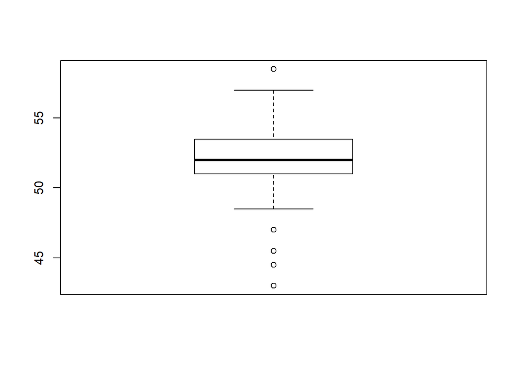

```r
boxplot(famil$ET0) # taille de l'enfant
```

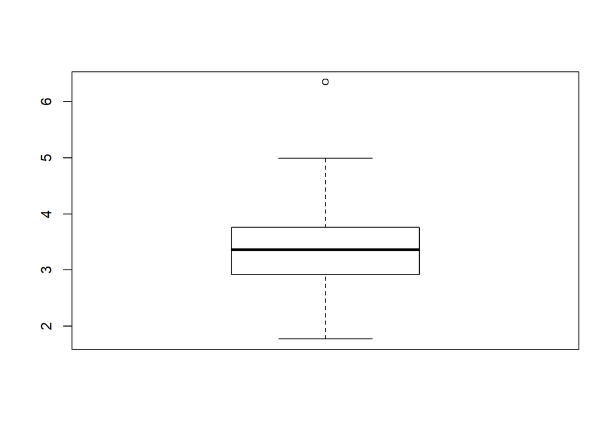

```r
boxplot(famil$EP0) # poids de l'enfant
```

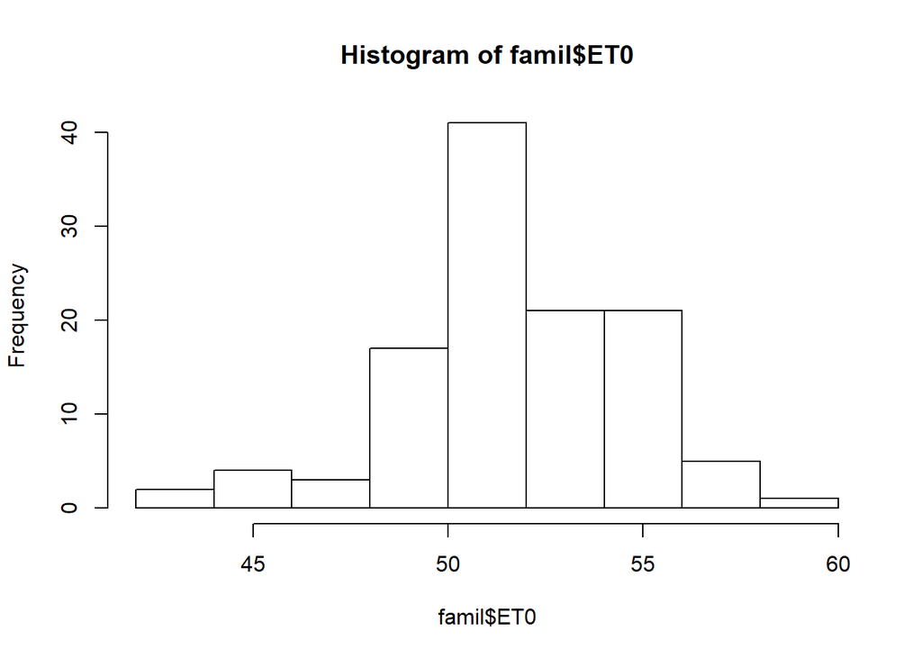

```r
hist(famil$ET0)
```

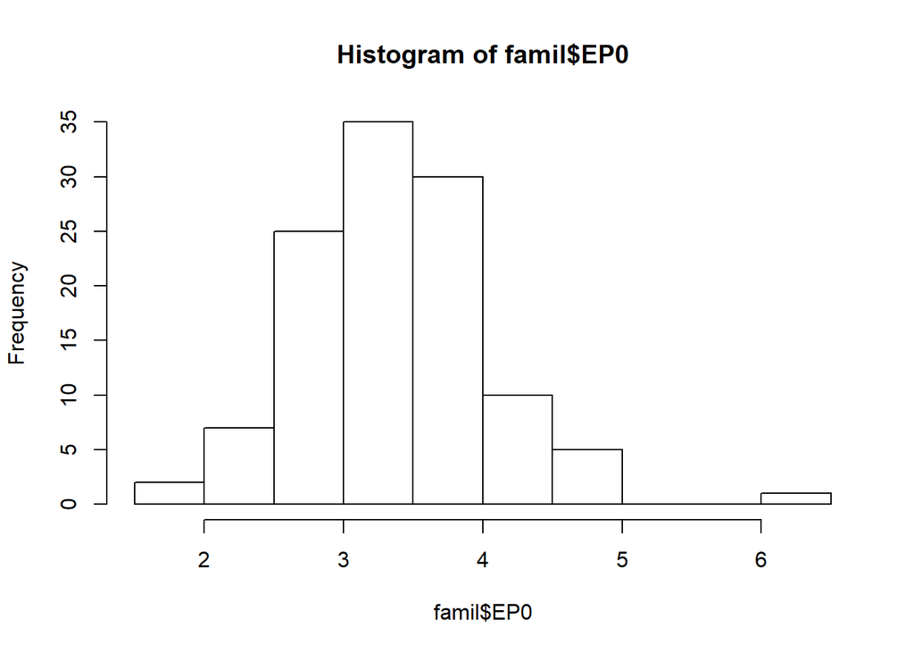

```r
hist(famil$EP0)
```

Pour les variables qualitatives, on aura plutôt tendance à considérer les fréquences des modalités.

```r
table(famil$ESx)
```

```
##
##  F  M
## 46 69
```

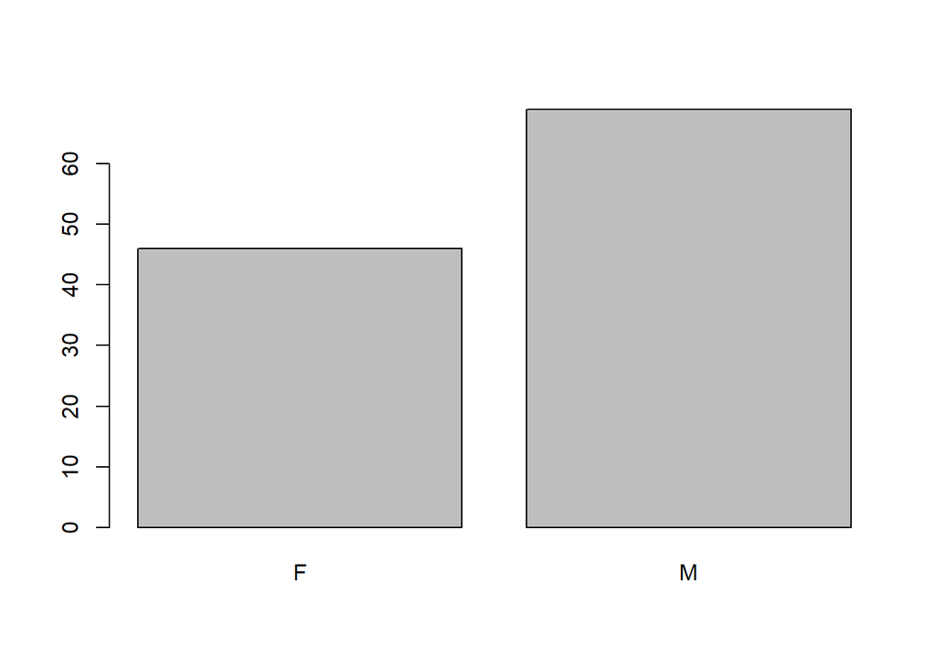

```r
barplot(table(famil$ESx)) # sexe de l'enfant
```

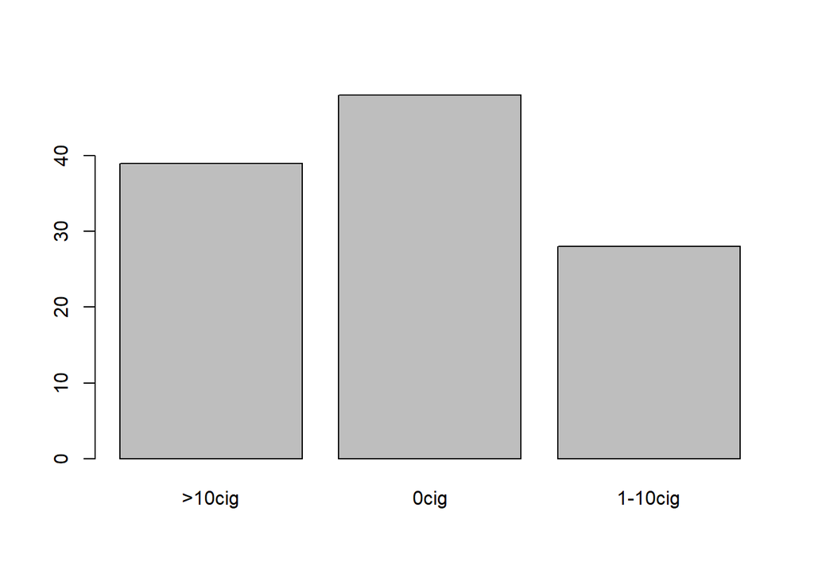

```r
barplot(table(famil$MCig0)) # consommation de cigarettes
```

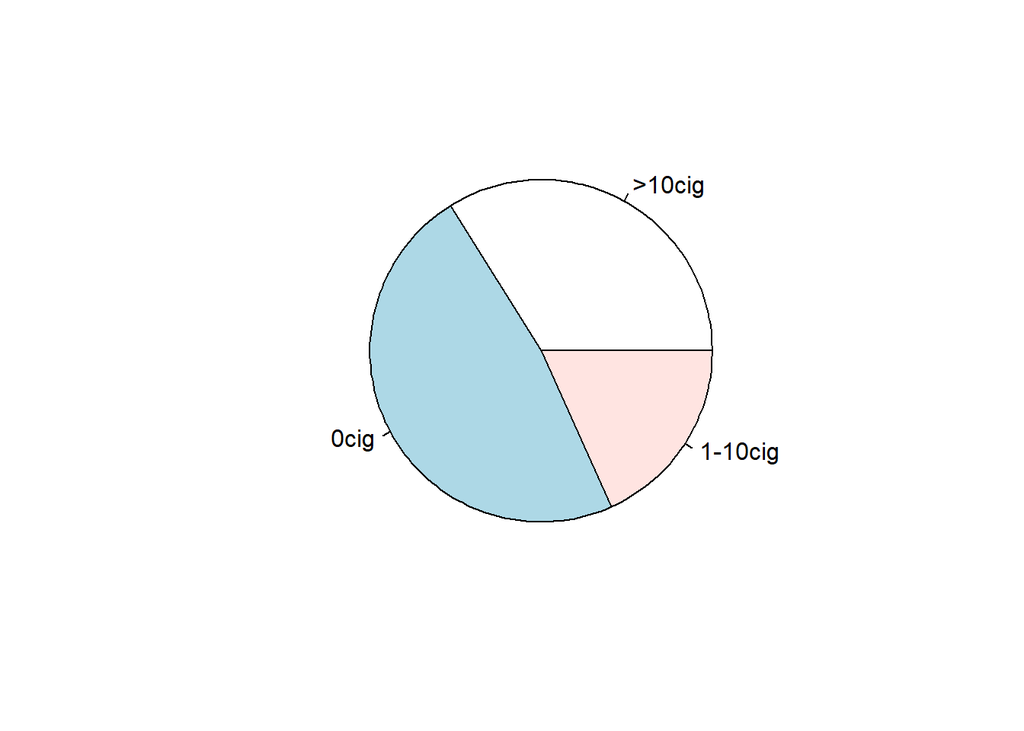

```r
pie(table(famil$MCig10)) # consommation de cigarettes dix ans après
```

Pour analyser grossièrement les liaisons, on peut regarder un nuage de points

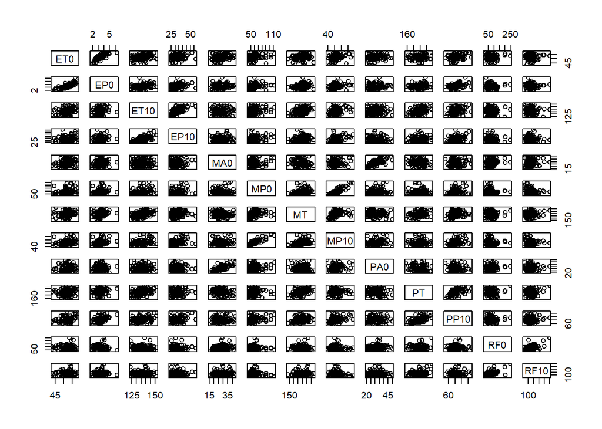

```r
pairs(famil[,c(3:6,8,9,11,12,14,16:19)])
```

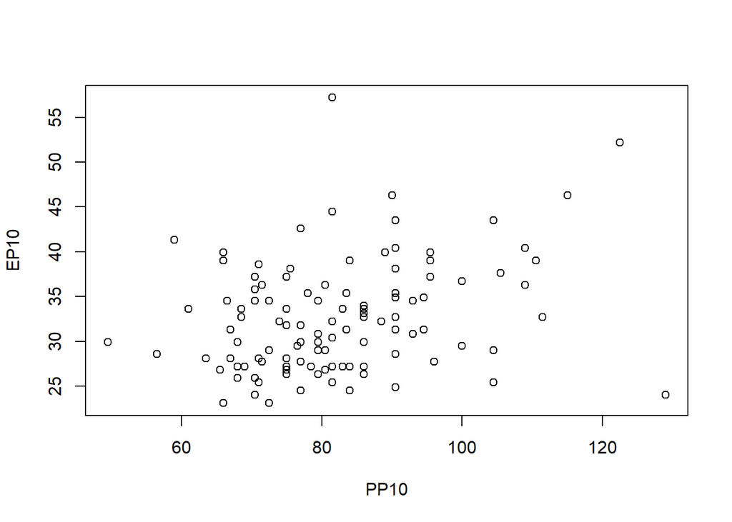

```r
plot(EP10~PP10,data=famil) # poids de l'enfant à 10 ans, poids du père
```

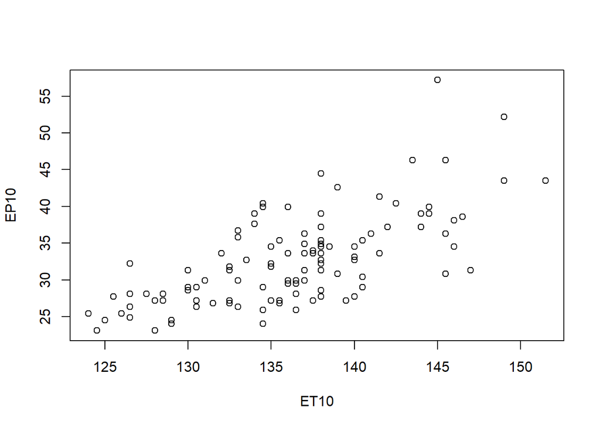

```r
plot(EP10~ET10,data=famil) # poids de l'enfant à 10 ans, taille à 10 ans
```

Pour analyser grossièrement les liaisons entre variables qualitatives, on aura recours aux tables de contingence

```r
table(famil$ESx,famil$ERh) # sexe et rhésus
```

```
##
##     R- R+
##   F  9 37
##   M 13 56
```

```r
addmargins(table(famil$ESx,famil$ERh)) # avec les marges
```

```
##
##        R-  R+ Sum
##   F     9  37  46
##   M    13  56  69
##   Sum  22  93 115
```

```r
prop.table(table(famil$ESx,famil$ERh)) # fréquences relatives
```

```
##
##             R-         R+
##   F 0.07826087 0.32173913
##   M 0.11304348 0.48695652
```

Une manière de représenter graphiquement ces tables est d’utiliser une moisaique

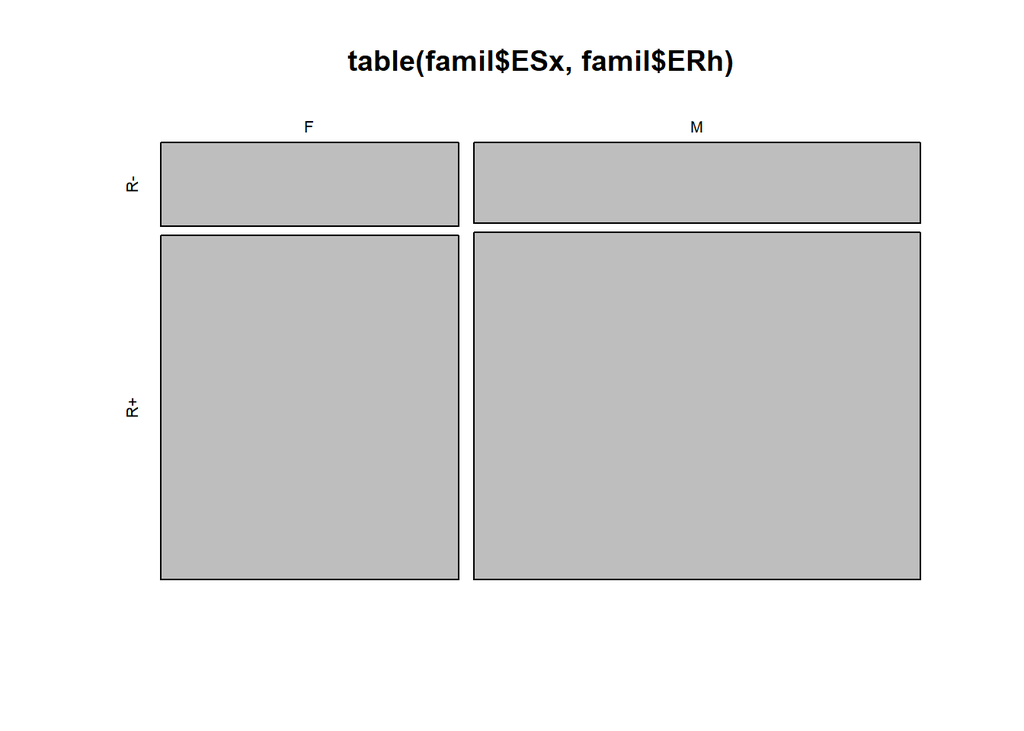

```r
mosaicplot(table(famil$ESx,famil$ERh))
```

```r
addmargins(table(famil$MCig0,famil$ESx)) # consommation de cigarette et sexe de l'enfant
```

```
##
##             F   M Sum
##   >10cig   11  28  39
##   0cig     27  21  48
##   1-10cig   8  20  28
##   Sum      46  69 115
```

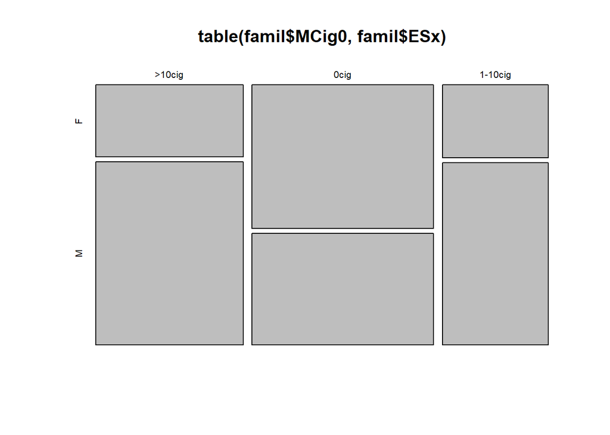

```r
mosaicplot(table(famil$MCig0,famil$ESx))
```

Si l’on veut croiser variables qualitatives et quantitatives, on peut utiliser les boites

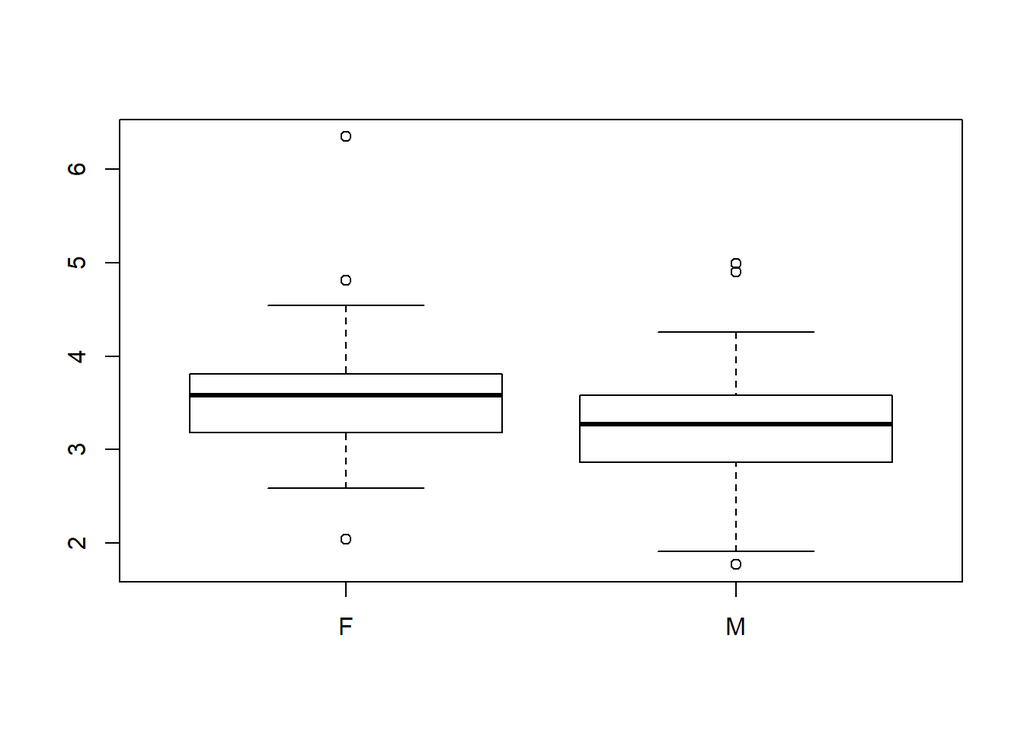

```r
boxplot(EP0~ESx,data=famil) # poids de l'enfant vs sexe
```

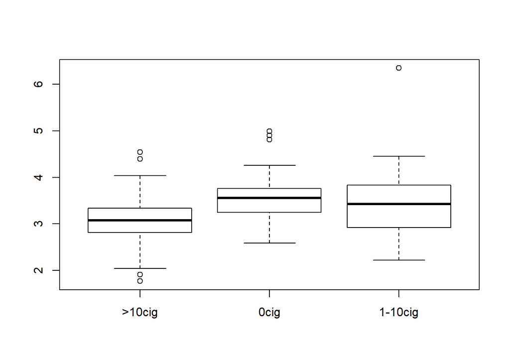

```r
boxplot(EP0~MCig0,data=famil) # poids de l'enfant vs consommation de cigarettes
```

### Tests de liaison

Quelques tests, imaginons qu’on veuille tester l’indépendance de deux variables qualitatives. Le test du $\Khi^2$ sera adapté à ce problème (dans le cas où les effectifs d’une modalité sont trop faibles, il faut regrouper les modalités).

```r
chisq.test(table(famil$ESx,famil$ERh)) # Sexe de l'enfant vs Rhésus
```

```
##
##  Pearson's Chi-squared test with Yates' continuity correction
##
## data:  table(famil$ESx, famil$ERh)
## X-squared = 5.6549e-31, df = 1, p-value = 1
```

```r
chisq.test(table(famil$ESx,famil$MCig0)) # Sexe de l'enfant vs consommation de cigarettes
```

```
##
##  Pearson's Chi-squared test
##
## data:  table(famil$ESx, famil$MCig0)
## X-squared = 9.0657, df = 2, p-value = 0.01075
```

On s’intéresse à l’influence du sexe sur la taille à la naissance. Tester l’égalité des deux moyennes nécessite de vérifier préalablement plusieurs points : la normalité des distributions dans chaque classe à moins que l’échantillon soit considéré de taille suffisamment grande, le caractère indépendant ou appariés des échantillons, l’égalité ou non des variances à l’intérieur de chaque groupe. On dispose de deux échantillons indépendants : les garçons et les filles. Testons les autres hypothèses.

```r
# Normalité des distributions (facultatif car n grand ici)
shapiro.test(famil[famil$ESx=="M","ET0"])
```

```
##
##  Shapiro-Wilk normality test
##
## data:  famil[famil$ESx == "M", "ET0"]
## W = 0.95676, p-value = 0.01779
```

```r
shapiro.test(famil[famil$ESx=="F","ET0"])
```

```
##
##  Shapiro-Wilk normality test
##
## data:  famil[famil$ESx == "F", "ET0"]
## W = 0.95141, p-value = 0.05315
```

```r
# égalité des variances (test de Fisher)
var.test(ET0~ESx,data=famil)
```

```
##
##  F test to compare two variances
##
## data:  ET0 by ESx
## F = 0.92761, num df = 45, denom df = 68, p-value = 0.7979
## alternative hypothesis: true ratio of variances is not equal to 1
## 95 percent confidence interval:
##  0.5495201 1.6132113
## sample estimates:
## ratio of variances
##          0.9276114
```

Le test de comparaison des moyennes à utiliser (Student vs. Welsh) dépend du résultat précédent concernant l’égalité des variances.

```r
t.test(ET0~ESx,var.equal=F, data=famil) # si les variances sont différentes c'est un test de Welsh
```

```
##
##  Welch Two Sample t-test
##
## data:  ET0 by ESx
## t = 2.9017, df = 99.064, p-value = 0.004573
## alternative hypothesis: true difference in means is not equal to 0
## 95 percent confidence interval:
##  0.5006535 2.6660131
## sample estimates:
## mean in group F mean in group M
##        52.88043        51.29710
```

```r
t.test(ET0~ESx,var.equal=T, data=famil) # Dans le cas où elles sont considérées égales, c'est un test de Student.
```

```
##
##  Two Sample t-test
##
## data:  ET0 by ESx
## t = 2.8798, df = 113, p-value = 0.004761
## alternative hypothesis: true difference in means is not equal to 0
## 95 percent confidence interval:
##  0.4940799 2.6725868
## sample estimates:
## mean in group F mean in group M
##        52.88043        51.29710
```

Dans le cas d’échantillons appariés, par exemple si on se propose d’étudier l’évolution du poids de la mère au moment de la naissance et dix ans après, on utilise l’option `paired=TRUE`

```r
t.test(famil$MP0, famil$MP10,paired=TRUE)
```

```
##
##  Paired t-test
##
## data:  famil$MP0 and famil$MP10
## t = -7.458, df = 114, p-value = 1.864e-11
## alternative hypothesis: true difference in means is not equal to 0
## 95 percent confidence interval:
##  -5.684285 -3.298324
## sample estimates:
## mean of the differences
##               -4.491304
```

Remarques : - si l’hypothèse de normalité des distributions n’est pas vérifiée et si l’échantillon est trop réduit, c’est un test non-paramétrique qu’il faut mettre en ouvre. Les tests non-paramétriques sont basés sur les rangs des observations et donc sur les comparaisons des médianes des échantillons (wilcoxson).

- Si l’on veut tester l’indépendance entre une variable qualitative et quantitative, l’ANOVA associée à un test de Fisher est sans doute le test le plus utilisé ; il revient au test de Student lorsque la variable qualitative n’a que deux modalités.

### Régression simple et multiple

La régression simple permet de tester l’influence éventuelle d’une variable sur une autre et plus précisément, dans le cas de cet exemple, d’expliquer la taille de l’enfant à 10 ans. On estime le modèle avec la fonction `lm`

```r
res1.reg=lm(ET10 ~ PT, data = famil)
names(res1.reg) # liste des résultats
```

```
##  [1] "coefficients"  "residuals"     "effects"       "rank"
##  [5] "fitted.values" "assign"        "qr"            "df.residual"
##  [9] "xlevels"       "call"          "terms"         "model"
```

Les graphiques suivants permettent de s’assurer de la validité du modèle, et notamment de statuer sur l’homoscédasticité des résidus, leur normalité, la bonne linéarité du modèle.

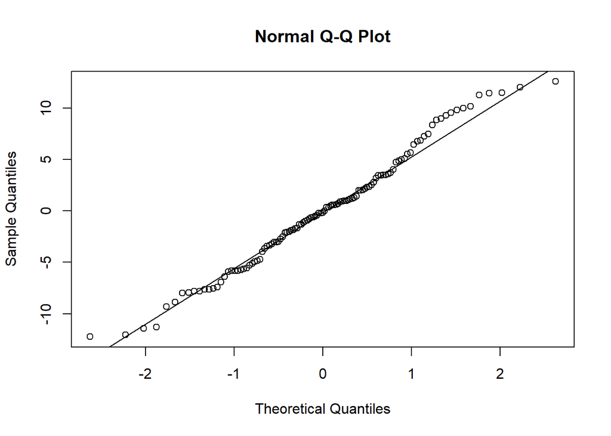

```r
qqnorm(res1.reg$residuals) # normalité des résidus
qqline(res1.reg$residuals)
```

```r
shapiro.test(res1.reg$residuals)
```

```
##
##  Shapiro-Wilk normality test
##
## data:  res1.reg$residuals
## W = 0.98511, p-value = 0.2346
```

Les résidus sont “grands” si, une fois normalisés ou plutôt “studentisés”, ils sont de valeur absolue plus grande que 2.

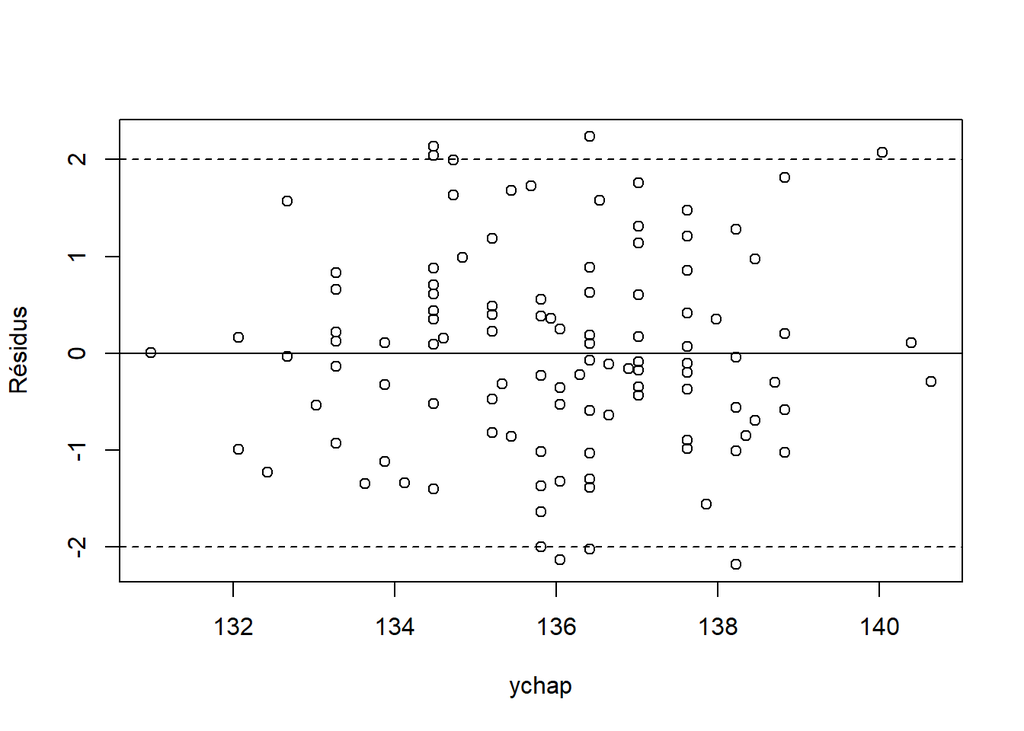

```r
res.student=rstudent(res1.reg)
ychap=res1.reg$fitted.values
plot(res.student~ychap,ylab="Résidus")
abline(h=c(-2,0,2),lty=c(2,1,2)) # rajoute une ligne horizontale
```

Une observation est influente si elle a un grand résidu est est associée à une grande valeur sur la diagonale de la hat matrix. Cela correspond à une valeur élevée (plus grande que 1) de la distance de Cook.

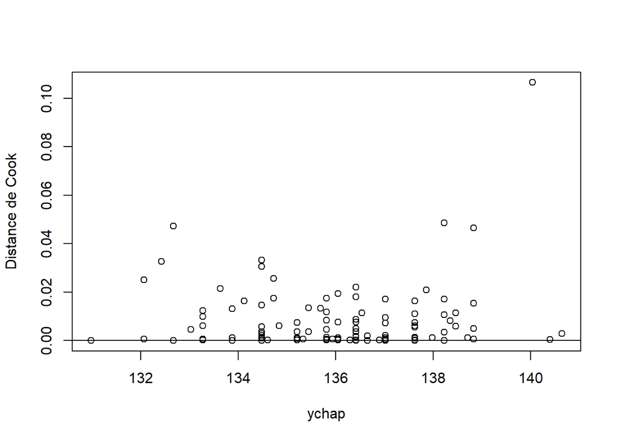

```r
cook=cooks.distance(res1.reg) # repérage de points influents
plot(cook~ychap,ylab="Distance de Cook")
abline(h=c(0,1),lty=c(1,2))
```

La significativité du modèle peut être analysée via la fonction `summary` :

```r
summary(res1.reg)
```

```
##
## Call:
## lm(formula = ET10 ~ PT, data = famil)
##
## Residuals:
##      Min       1Q   Median       3Q      Max
## -12.2297  -3.8156  -0.1753   3.4956  12.5815
##
## Coefficients:
##             Estimate Std. Error t value Pr(>|t|)
## (Intercept) 92.82881   12.44735   7.458 1.94e-11 ***
## PT           0.24149    0.06949   3.475 0.000725 ***
## ---
## Signif. codes:  0 '***' 0.001 '**' 0.01 '*' 0.05 '.' 0.1 ' ' 1
##
## Residual standard error: 5.751 on 113 degrees of freedom
## Multiple R-squared:  0.09657,    Adjusted R-squared:  0.08857
## F-statistic: 12.08 on 1 and 113 DF,  p-value: 0.0007246
```

La régression linéaire simple conduit à un modèle très mal ajusté. Le modèle linéaire multiple ci-dessous, plus complexe, recherche un meilleur ajustement des données.

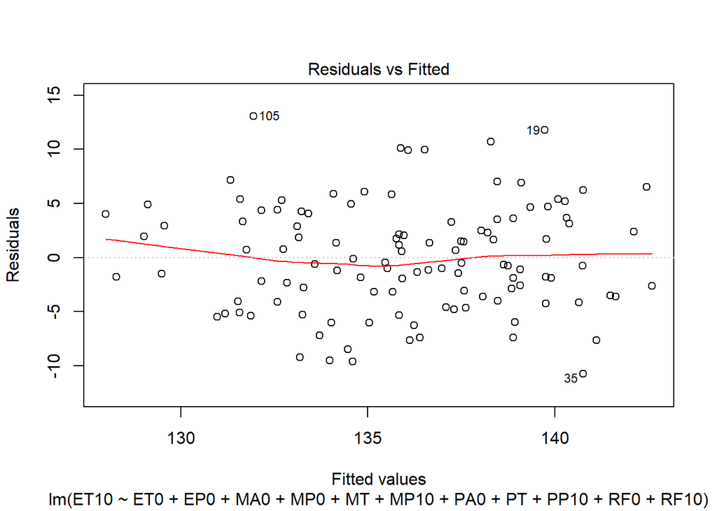

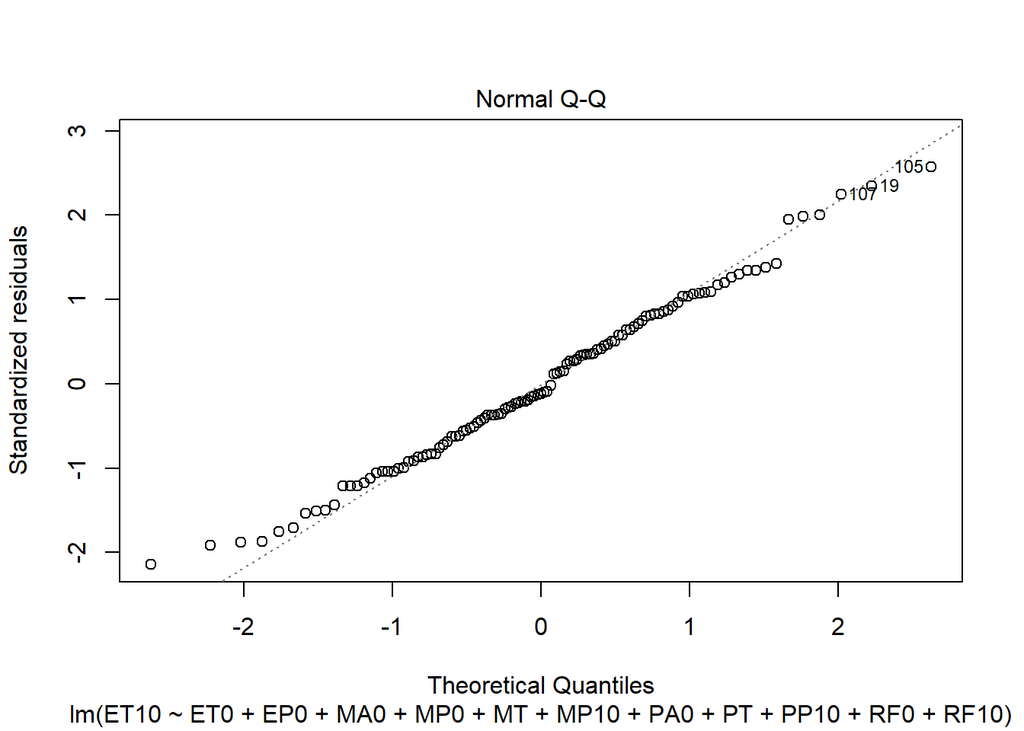

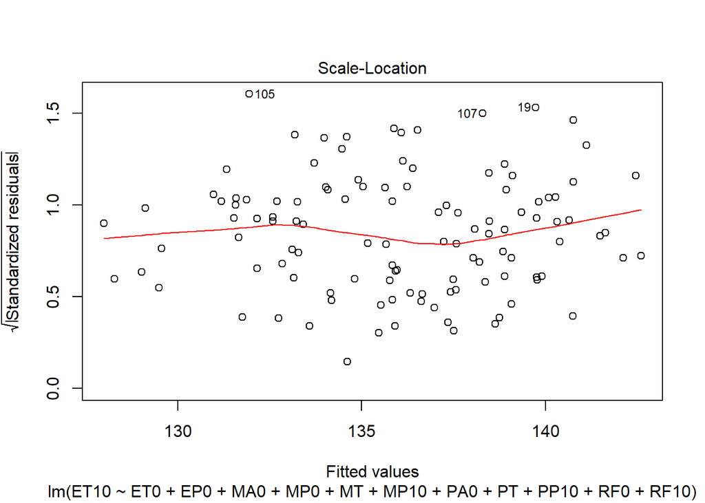

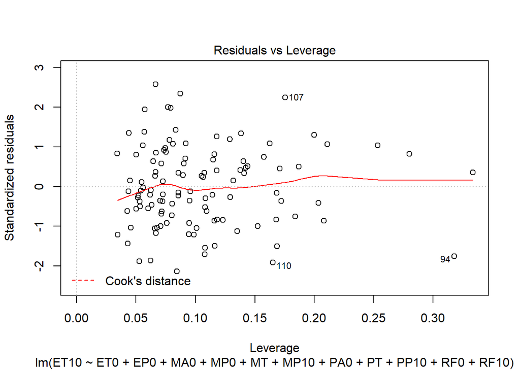

```r
res2.reg=lm(ET10~ET0+EP0+MA0+MP0+MT+MP10+PA0+PT+PP10+RF0+RF10, data = famil)
plot(res2.reg) # diagnostics des résidus
```

```r
summary(res2.reg) # résultats
```

```
##
## Call:
## lm(formula = ET10 ~ ET0 + EP0 + MA0 + MP0 + MT + MP10 + PA0 +
##     PT + PP10 + RF0 + RF10, data = famil)
##
## Residuals:
##     Min      1Q  Median      3Q     Max
## -10.753  -3.605  -0.583   3.575  13.055
##
## Coefficients:
##              Estimate Std. Error t value Pr(>|t|)
## (Intercept) 19.395052  22.732841   0.853  0.39554
## ET0          0.603298   0.293976   2.052  0.04269 *
## EP0         -1.024211   1.330923  -0.770  0.44333
## MA0         -0.070042   0.149033  -0.470  0.63937
## MP0         -0.066802   0.082435  -0.810  0.41961
## MT           0.346222   0.107974   3.207  0.00179 **
## MP10         0.078521   0.079884   0.983  0.32794
## PA0          0.147236   0.130401   1.129  0.26148
## PT           0.154598   0.089309   1.731  0.08644 .
## PP10         0.035471   0.050199   0.707  0.48140
## RF0         -0.007751   0.016938  -0.458  0.64819
## RF10        -0.010480   0.008614  -1.217  0.22652
## ---
## Signif. codes:  0 '***' 0.001 '**' 0.01 '*' 0.05 '.' 0.1 ' ' 1
##
## Residual standard error: 5.245 on 103 degrees of freedom
## Multiple R-squared:  0.3152, Adjusted R-squared:  0.242
## F-statistic: 4.309 on 11 and 103 DF,  p-value: 2.792e-05
```

### ACP

On peut aller plus loin dans l’exploration sur les données sans fixer une variable cible, en réalisant une analyse en composantes principales. On ne garde que les variables quantitatives.

Pour cela, on va faire appel à la librairie `prcomp`, ce n’est pas la seule qui permet de faire une ACP. Assez régulièrement sous R, on va avoir besoin de mobiliser des packages ou librairies. La liste complète des packages disponibles gratuitement est consultable sur le site du CRAN. L’installation d’un package supplémentaire peut se faire via le menu Packages>Installer le(s) package(s) et en choisissant un site miroir du CRAN. On peut également télécharger l’archive .zip correspondant au package et utiliser ensuite Packages/Installer depuis des fichiers zip

On peut sinon taper la commande :

```r
#install.packages('prcomp') # décommenter pour installer
```

```r
data=famil[,c(3:6,8,9,11,12,14,16:19)] # liste des varaibles quantitatives

noms=dimnames(data)[[2]];noms
```

```
##  [1] "ET0"  "EP0"  "ET10" "EP10" "MA0"  "MP0"  "MT"   "MP10" "PA0"  "PT"
## [11] "PP10" "RF0"  "RF10"
```

```r
names(data)
```

```
##  [1] "ET0"  "EP0"  "ET10" "EP10" "MA0"  "MP0"  "MT"   "MP10" "PA0"  "PT"
## [11] "PP10" "RF0"  "RF10"
```

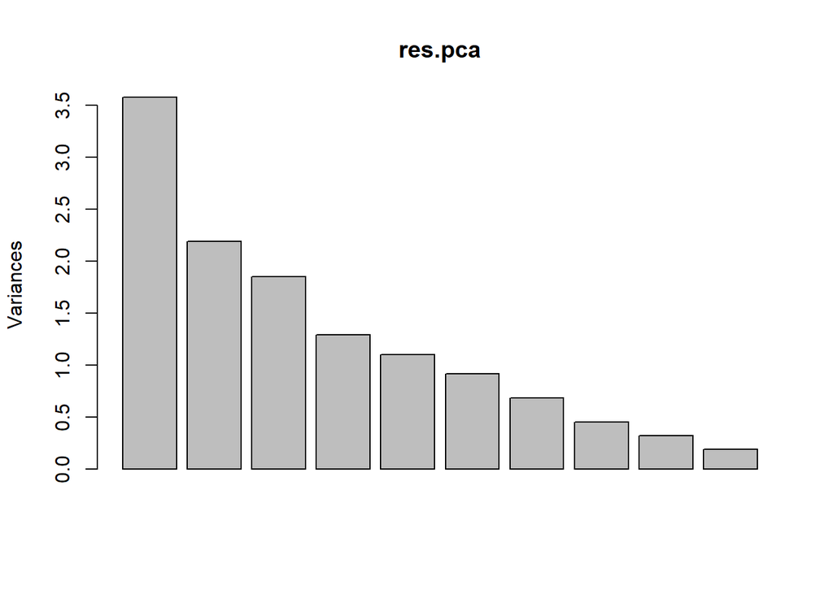

```r
res.pca=prcomp(data,scale=T)
plot(res.pca) # décroissance des valeurs propres
```

```r
summary(res.pca) # parts de variance expliquée
```

```
## Importance of components%s:
##                           PC1    PC2    PC3     PC4     PC5     PC6
## Standard deviation     1.8915 1.4792 1.3594 1.13565 1.04918 0.95572
## Proportion of Variance 0.2752 0.1683 0.1422 0.09921 0.08468 0.07026
## Cumulative Proportion  0.2752 0.4435 0.5857 0.68488 0.76956 0.83982
##                            PC7     PC8     PC9    PC10   PC11    PC12
## Standard deviation     0.82493 0.66919 0.56744 0.43219 0.4281 0.39240
## Proportion of Variance 0.05235 0.03445 0.02477 0.01437 0.0141 0.01184
## Cumulative Proportion  0.89217 0.92661 0.95138 0.96575 0.9798 0.99169
##                           PC13
## Standard deviation     0.32870
## Proportion of Variance 0.00831
## Cumulative Proportion  1.00000
```

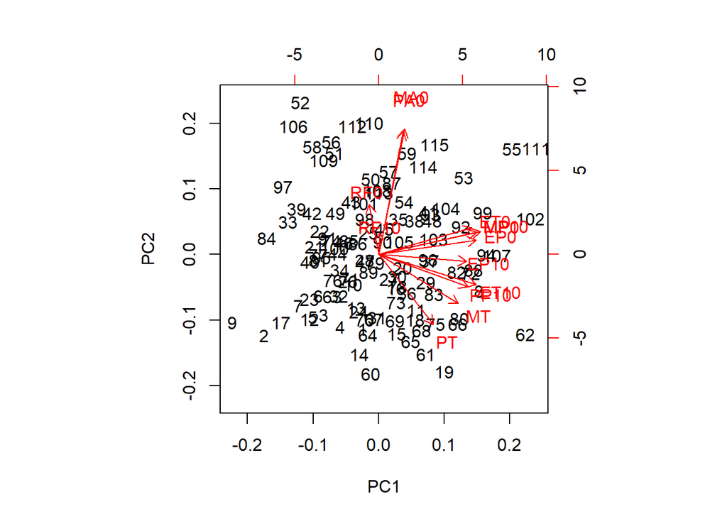

```r
biplot(res.pca) # biplot du premier plan principal
```

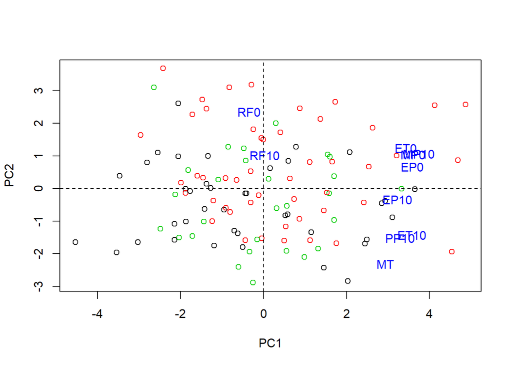

```r
plot(res.pca$x,col=as.integer(famil$MCig0))
text(10*res.pca$rotation,noms,col="blue")
abline(h=0,v=0,lty=2)
```

# Exploration avancée (dplyr + ggplot2) sur données des urgences

- lecture ecriture fichier sas et xls
- dplyr et ggplot2 (croiser délai d’attente et personnel)
- gestion des valeurs manquantes
- leaflet sur la loc des urgences